# Airline customer satisfaction project

2023-03-29

# 1 Introduction

## 1.1 Data description

This data set contains a survey **on air passenger satisfaction**. The following **classification problem** is set:

It is necessary to predict which of the **two** levels of satisfaction with the airline the passenger belongs to:

**1. Satisfaction (54.8%)**  
**2. dissatisfied (45.2%)**

In this project, we will apply various models:  
**-Logistic regression**  
**-Factorial Discriminant Analysis**  
**-Decision Tree**  
**-RandomForest**

## 1.2 Variables

There is the following information about the passengers of some airline:

1. **Gender**: male or female
2. **Customer type**: regular or non-regular airline customer *(loyal or disloyal Customer)*
3. **Age**: the actual age of the passenger
4. **Type of travel**: the purpose of the passenger’s flight *(personal or business travel)*
5. **Class**: the type of the seat in the plane *(business, economy, economy plus)*
6. **Flight distance**: The distance that the costumer will travel
7. **Seat comfort**: seat satisfaction level *(0: not rated; 1-5)*
8. **Departure/Arrival time convenient**: departure/arrival time satisfaction level *(0: not rated; 1-5)*
9. **Food and drink**: food and drink satisfaction level *(0: not rated; 1-5)*
10. **Gate location**: level of satisfaction with the gate location *(0: not rated; 1-5)*
11. **Inflight wifi service**: satisfaction level with Wi-Fi service on board *(0: not rated; 1-5)*
12. **Inflight entertainment**: satisfaction with inflight entertainment *(0: not rated; 1-5)*
13. **Online Support**: level of satisfaction of the online guideness *(0: not rated; 1-5)*
14. **Ease of Online booking**: online booking satisfaction rate *(0: not rated; 1-5)*
15. **On-board service**: level of satisfaction with on-board service *(0: not rated; 1-5)*
16. **Leg room service**: level of satisfaction with leg room service *(0: not rated; 1-5)*
17. **Baggage handling**: level of satisfaction with baggage handling *(0: not rated; 1-5)*
18. **Checkin service**: level of satisfaction with checkin service *(0: not rated; 1-5)*
19. **Cleanliness**: level of satisfaction with cleanliness *(0: not rated; 1-5)*
20. **Online boarding**: satisfaction level with online boarding *(0: not rated; 1-5)*
21. **Departure delay in minutes**
22. **Arrival delay in minutes**

## 1.3 Loading Data

```r
df=read.csv("C:/Users/hamed/Desktop/ESSAI/data mining/Invistico_Airline.csv")
head(df)
```

```
##   satisfaction Gender  Customer.Type Age  Type.of.Travel    Class
## 1    satisfied Female Loyal Customer  65 Personal Travel      Eco
## 2    satisfied   Male Loyal Customer  47 Personal Travel Business
## 3    satisfied Female Loyal Customer  15 Personal Travel      Eco
## 4    satisfied Female Loyal Customer  60 Personal Travel      Eco
## 5    satisfied Female Loyal Customer  70 Personal Travel      Eco
## 6    satisfied   Male Loyal Customer  30 Personal Travel      Eco
##   Flight.Distance Seat.comfort Departure.Arrival.time.convenient Food.and.drink
## 1             265            0                                 0              0
## 2            2464            0                                 0              0
## 3            2138            0                                 0              0
## 4             623            0                                 0              0
## 5             354            0                                 0              0
## 6            1894            0                                 0              0
##   Gate.location Inflight.wifi.service Inflight.entertainment Online.support
```

[output cut: 27 more lines]

# 2 Data Manipulation

I created a function to check the NAs values in each column or the data frame

```r
stats=function(df){
    l=c()
    for(i in 1:length(df)){
        type=class(df[,i])
        unique=length(unique(df[,i]))
        sum_null=sum(is.na(df[,i]))
        l=append(l,c(colnames(df)[i],type,unique,sum_null))
    }
    df_stats=matrix(l,ncol=4,byrow=T)
    colnames(df_stats)=c('column','type','unique','sum_null')
    return (df_stats)
}
stats(df)
```

```
##       column                              type        unique sum_null
##  [1,] "satisfaction"                      "character" "2"    "0"
##  [2,] "Gender"                            "character" "2"    "0"
##  [3,] "Customer.Type"                     "character" "2"    "0"
##  [4,] "Age"                               "integer"   "75"   "0"
##  [5,] "Type.of.Travel"                    "character" "2"    "0"
##  [6,] "Class"                             "character" "3"    "0"
##  [7,] "Flight.Distance"                   "integer"   "5398" "0"
##  [8,] "Seat.comfort"                      "integer"   "6"    "0"
##  [9,] "Departure.Arrival.time.convenient" "integer"   "6"    "0"
## [10,] "Food.and.drink"                    "integer"   "6"    "0"
## [11,] "Gate.location"                     "integer"   "6"    "0"
## [12,] "Inflight.wifi.service"             "integer"   "6"    "0"
## [13,] "Inflight.entertainment"            "integer"   "6"    "0"
## [14,] "Online.support"                    "integer"   "6"    "0"
## [15,] "Ease.of.Online.booking"            "integer"   "6"    "0"
## [16,] "On.board.service"                  "integer"   "6"    "0"
## [17,] "Leg.room.service"                  "integer"   "6"    "0"
## [18,] "Baggage.handling"                  "integer"   "5"    "0"
## [19,] "Checkin.service"                   "integer"   "6"    "0"
## [20,] "Cleanliness"                       "integer"   "6"    "0"
## [21,] "Online.boarding"                   "integer"   "6"    "0"
## [22,] "Departure.Delay.in.Minutes"        "integer"   "466"  "0"
## [23,] "Arrival.Delay.in.Minutes"          "integer"   "473"  "393"
```

As we can see, only the last variable **Arrival.Delay.in.Minutes** which has NAs values, so we will change the NAs with the same value as **Departure.Delay.in.Minutes** because i noticed that most values of the two variables are equals or close.

```r
df$Arrival.Delay.in.Minutes=ifelse(is.na(df$Arrival.Delay.in.Minutes),df$Departure.Delay.in.Minutes,df$Arrival.Delay.in.Minutes)
```

now we check if still any NA values.

```r
stats(df)
```

```
##       column                              type        unique sum_null
##  [1,] "satisfaction"                      "character" "2"    "0"
##  [2,] "Gender"                            "character" "2"    "0"
##  [3,] "Customer.Type"                     "character" "2"    "0"
##  [4,] "Age"                               "integer"   "75"   "0"
##  [5,] "Type.of.Travel"                    "character" "2"    "0"
##  [6,] "Class"                             "character" "3"    "0"
##  [7,] "Flight.Distance"                   "integer"   "5398" "0"
##  [8,] "Seat.comfort"                      "integer"   "6"    "0"
##  [9,] "Departure.Arrival.time.convenient" "integer"   "6"    "0"
## [10,] "Food.and.drink"                    "integer"   "6"    "0"
## [11,] "Gate.location"                     "integer"   "6"    "0"
## [12,] "Inflight.wifi.service"             "integer"   "6"    "0"
## [13,] "Inflight.entertainment"            "integer"   "6"    "0"
## [14,] "Online.support"                    "integer"   "6"    "0"
## [15,] "Ease.of.Online.booking"            "integer"   "6"    "0"
## [16,] "On.board.service"                  "integer"   "6"    "0"
## [17,] "Leg.room.service"                  "integer"   "6"    "0"
## [18,] "Baggage.handling"                  "integer"   "5"    "0"
## [19,] "Checkin.service"                   "integer"   "6"    "0"
## [20,] "Cleanliness"                       "integer"   "6"    "0"
## [21,] "Online.boarding"                   "integer"   "6"    "0"
## [22,] "Departure.Delay.in.Minutes"        "integer"   "466"  "0"
## [23,] "Arrival.Delay.in.Minutes"          "integer"   "475"  "0"
```

# 3 General Statistics

Starting with a full summary of the dataframe.

```r
summary(df)
```

```
##  satisfaction          Gender          Customer.Type           Age
##  Length:129880      Length:129880      Length:129880      Min.   : 7.00
##  Class :character   Class :character   Class :character   1st Qu.:27.00
##  Mode  :character   Mode  :character   Mode  :character   Median :40.00
##                                                           Mean   :39.43
##                                                           3rd Qu.:51.00
##                                                           Max.   :85.00
##  Type.of.Travel        Class           Flight.Distance  Seat.comfort
##  Length:129880      Length:129880      Min.   :  50    Min.   :0.000
##  Class :character   Class :character   1st Qu.:1359    1st Qu.:2.000
##  Mode  :character   Mode  :character   Median :1925    Median :3.000
##                                        Mean   :1981    Mean   :2.839
##                                        3rd Qu.:2544    3rd Qu.:4.000
##                                        Max.   :6951    Max.   :5.000
##  Departure.Arrival.time.convenient Food.and.drink  Gate.location
##  Min.   :0.000                     Min.   :0.000   Min.   :0.00
##  1st Qu.:2.000                     1st Qu.:2.000   1st Qu.:2.00
##  Median :3.000                     Median :3.000   Median :3.00
##  Mean   :2.991                     Mean   :2.852   Mean   :2.99
##  3rd Qu.:4.000                     3rd Qu.:4.000   3rd Qu.:4.00
##  Max.   :5.000                     Max.   :5.000   Max.   :5.00
##  Inflight.wifi.service Inflight.entertainment Online.support
##  Min.   :0.000         Min.   :0.000          Min.   :0.00
##  1st Qu.:2.000         1st Qu.:2.000          1st Qu.:3.00
##  Median :3.000         Median :4.000          Median :4.00
##  Mean   :3.249         Mean   :3.383          Mean   :3.52
##  3rd Qu.:4.000         3rd Qu.:4.000          3rd Qu.:5.00
##  Max.   :5.000         Max.   :5.000          Max.   :5.00
##  Ease.of.Online.booking On.board.service Leg.room.service Baggage.handling
##  Min.   :0.000          Min.   :0.000    Min.   :0.000    Min.   :1.000
##  1st Qu.:2.000          1st Qu.:3.000    1st Qu.:2.000    1st Qu.:3.000
##  Median :4.000          Median :4.000    Median :4.000    Median :4.000
##  Mean   :3.472          Mean   :3.465    Mean   :3.486    Mean   :3.696
##  3rd Qu.:5.000          3rd Qu.:4.000    3rd Qu.:5.000    3rd Qu.:5.000
##  Max.   :5.000          Max.   :5.000    Max.   :5.000    Max.   :5.000
##  Checkin.service  Cleanliness    Online.boarding Departure.Delay.in.Minutes
##  Min.   :0.000   Min.   :0.000   Min.   :0.000   Min.   :   0.00
##  1st Qu.:3.000   1st Qu.:3.000   1st Qu.:2.000   1st Qu.:   0.00
##  Median :3.000   Median :4.000   Median :4.000   Median :   0.00
##  Mean   :3.341   Mean   :3.706   Mean   :3.353   Mean   :  14.71
##  3rd Qu.:4.000   3rd Qu.:5.000   3rd Qu.:4.000   3rd Qu.:  12.00
##  Max.   :5.000   Max.   :5.000   Max.   :5.000   Max.   :1592.00
##  Arrival.Delay.in.Minutes
##  Min.   :   0.00
##  1st Qu.:   0.00
##  Median :   0.00
##  Mean   :  15.16
##  3rd Qu.:  13.00
##  Max.   :1584.00
```

Next we have some visualizations of certain variables of the dataframe.

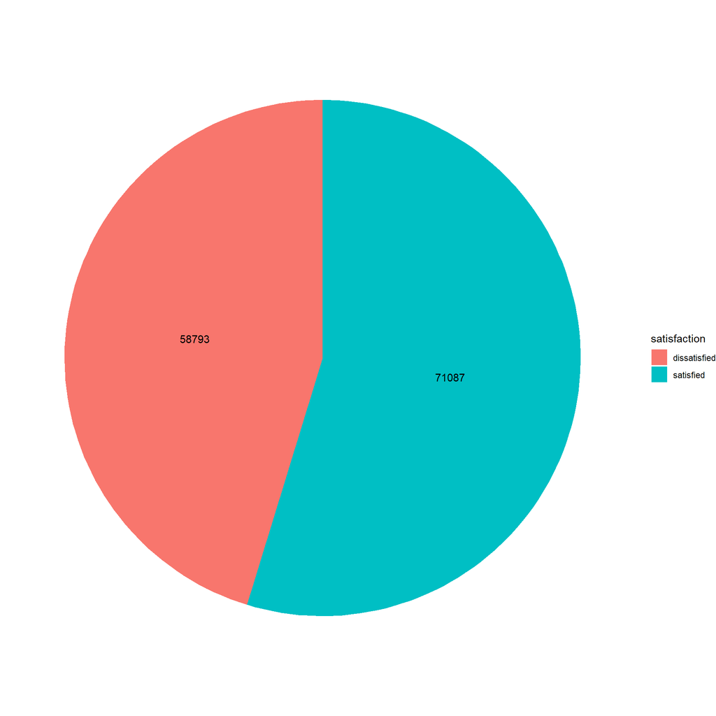

```r
data.pie=data.frame(df%>%
                      group_by(satisfaction)%>%
                      summarise(count=n()))
ggplot(data.pie, aes(x="", y=count, fill=satisfaction)) +
  geom_bar(stat="identity", width=1) +
  coord_polar("y", start=0) +
  geom_text(aes(label = count),
            position = position_stack(vjust = 0.5)) +
  theme_void()
```

Here we have the distribution of the **satisfied** and the **dissatisfied** clients we can see more satisfied than the dissatisfied ones.

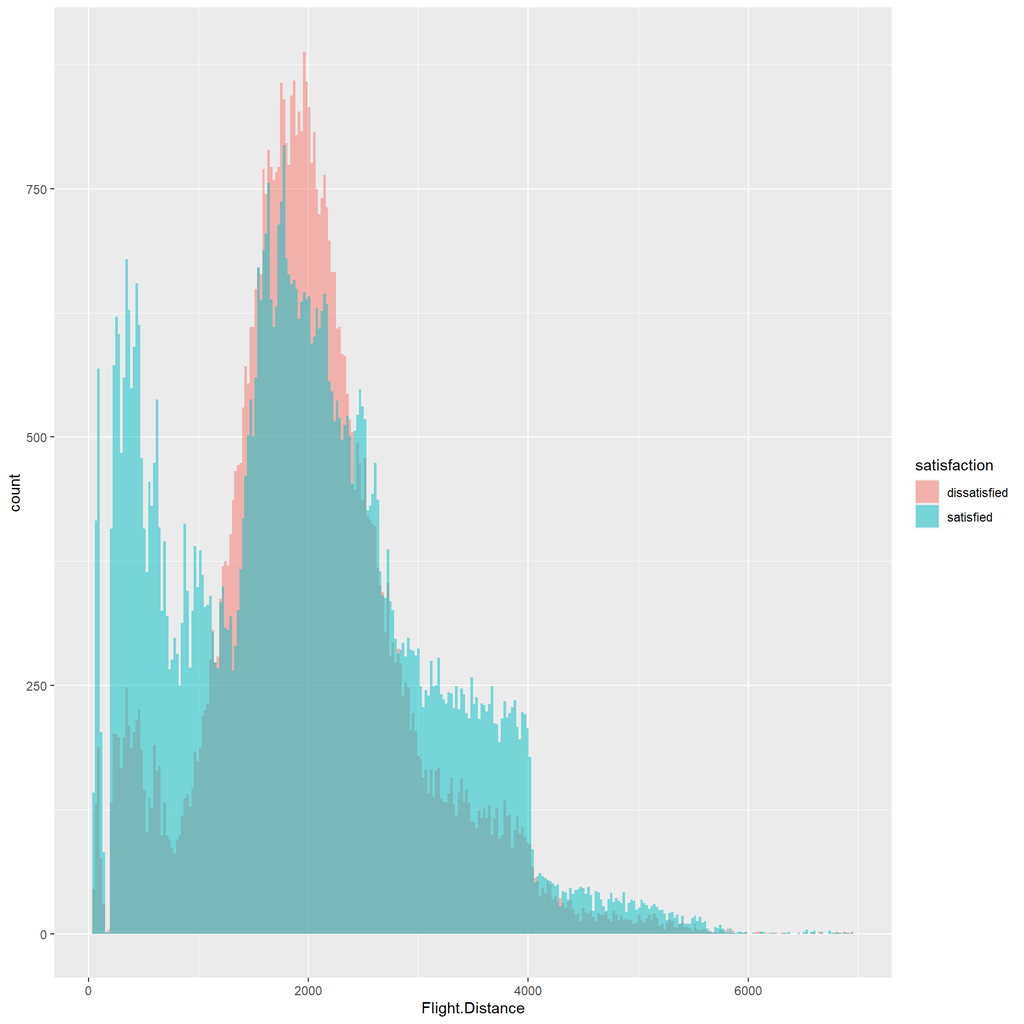

```r
ggplot(df, aes(x=Flight.Distance, fill=satisfaction)) +
  geom_histogram(alpha=0.5,bins=300,position='identity')
```

Here is the distribution of the costumers dependently on the distance of the flight where we have in the majority of the short-distance flights, the clients are satisfied but for the mid-range distance between **1100** and **2500**, the clients are not satisfied and then for the long-range we have back the dominance of the satisfaction.

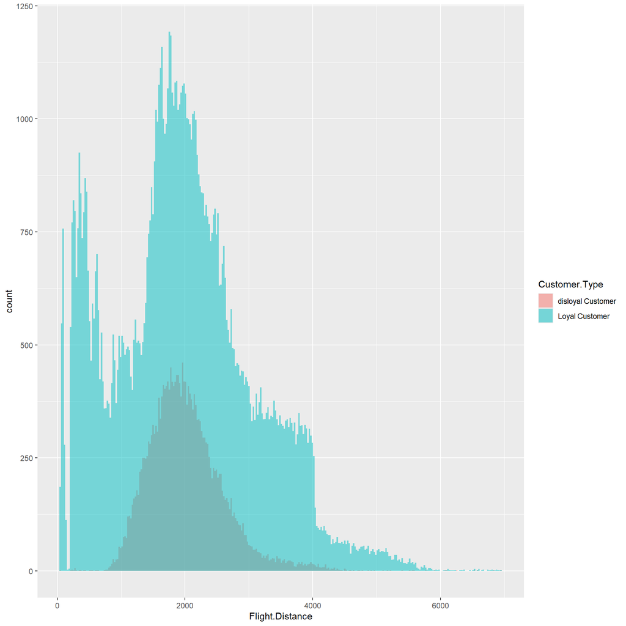

```r
ggplot(df, aes(x=Flight.Distance, fill=Customer.Type)) +
  geom_histogram(alpha=0.5,bins=300,position='identity')
```

Here for the loyalty of the customers, we have the majority of the customers are loyal for the company and the majority of the disloyal customers are getting mid-range flights.

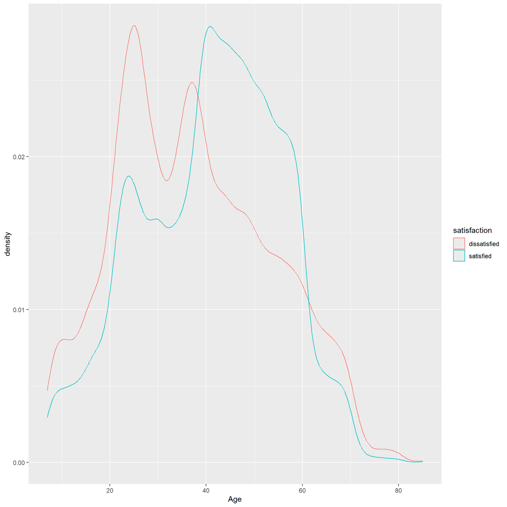

```r
ggplot(df, aes(x=Age, color=satisfaction)) +geom_density()
```

for ages, we have mostly independence between satisfaction and the age factor, except for the range of ages between **38** and **62** where we have high satisfaction rate and slightly higher dissatisfaction for younger ages.

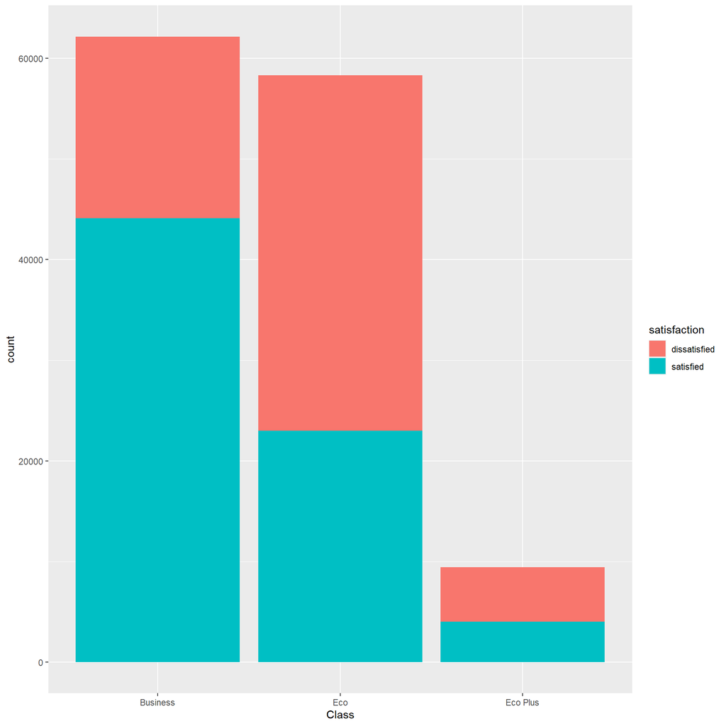

```r
ggplot(df,aes(x=Class,fill=satisfaction))+geom_bar()
```

As u can see, most of the costumers are with **business** class but most of the dissatisfied costumers are taking the **Eco** class and just few of them are in **eco plus** class.

# 4 Analysing Data

## 4.1 Principal Component Analysis

For this part we will be taking a look on on the PCA but firstly we need to select the categorical variables. for this purpose I created a function to select those variables dependently on the number of unique values.

```r
discrete= function(x){
    length(unique(x)) <= 6
}
sapply(df, discrete)
```

```
##                      satisfaction                            Gender
##                              TRUE                              TRUE
##                     Customer.Type                               Age
##                              TRUE                             FALSE
##                    Type.of.Travel                             Class
##                              TRUE                              TRUE
##                   Flight.Distance                      Seat.comfort
##                             FALSE                              TRUE
## Departure.Arrival.time.convenient                    Food.and.drink
##                              TRUE                              TRUE
##                     Gate.location             Inflight.wifi.service
##                              TRUE                              TRUE
##            Inflight.entertainment                    Online.support
##                              TRUE                              TRUE
##            Ease.of.Online.booking                  On.board.service
##                              TRUE                              TRUE
##                  Leg.room.service                  Baggage.handling
##                              TRUE                              TRUE
##                   Checkin.service                       Cleanliness
##                              TRUE                              TRUE
##                   Online.boarding        Departure.Delay.in.Minutes
##                              TRUE                             FALSE
##          Arrival.Delay.in.Minutes
##                             FALSE
```

when we look at the **stats** function we could see that the required variables have maximum 6 levels and with the use of the **sapply** function we get the result above of the required variables then we select the chosen variables from the dataframe.

```r
pca_df=df[,sapply(df,discrete)]
head(pca_df)
```

```
##   satisfaction Gender  Customer.Type  Type.of.Travel    Class Seat.comfort
## 1    satisfied Female Loyal Customer Personal Travel      Eco            0
## 2    satisfied   Male Loyal Customer Personal Travel Business            0
## 3    satisfied Female Loyal Customer Personal Travel      Eco            0
## 4    satisfied Female Loyal Customer Personal Travel      Eco            0
## 5    satisfied Female Loyal Customer Personal Travel      Eco            0
## 6    satisfied   Male Loyal Customer Personal Travel      Eco            0
##   Departure.Arrival.time.convenient Food.and.drink Gate.location
## 1                                 0              0             2
## 2                                 0              0             3
## 3                                 0              0             3
## 4                                 0              0             3
## 5                                 0              0             3
## 6                                 0              0             3
##   Inflight.wifi.service Inflight.entertainment Online.support
```

[output cut: 20 more lines]

as u can see, the first 5 columns are string categorical variables and the PCA function works on the numerical variables so if we apply the **as.numeric** function directly on the dataframe, all the string variables will become **NAs**.  
So my solution was to apply firstly **as.factor** then apply the **as.numeric**, that way, all the string categorical variables will be numeric categorical automatically.

```r
pca_df[]=lapply(pca_df,factor)
pca_df[]=lapply(pca_df,as.integer)
head(pca_df)
```

```
##   satisfaction Gender Customer.Type Type.of.Travel Class Seat.comfort
## 1            2      1             2              2     2            1
## 2            2      2             2              2     1            1
## 3            2      1             2              2     2            1
## 4            2      1             2              2     2            1
## 5            2      1             2              2     2            1
## 6            2      2             2              2     2            1
##   Departure.Arrival.time.convenient Food.and.drink Gate.location
## 1                                 1              1             3
## 2                                 1              1             4
## 3                                 1              1             4
## 4                                 1              1             4
## 5                                 1              1             4
## 6                                 1              1             4
##   Inflight.wifi.service Inflight.entertainment Online.support
```

[output cut: 20 more lines]

and the problem is solved but we have another problem which the large number of rows *(129880)* that may cause a problem for the PCA function so it is required to make changes on the data to make it easier.

```r
pca_df2=summaryBy(.~ satisfaction+Gender+Customer.Type+Type.of.Travel+Class,data = pca_df,FUN=c(mean),keep.names = TRUE)
dim(pca_df2)
```

```
## [1] 43 19
```

Now we have a huge reduction of the large number of rows which is **43** now. and the data is ready for applying the **PCA** function.

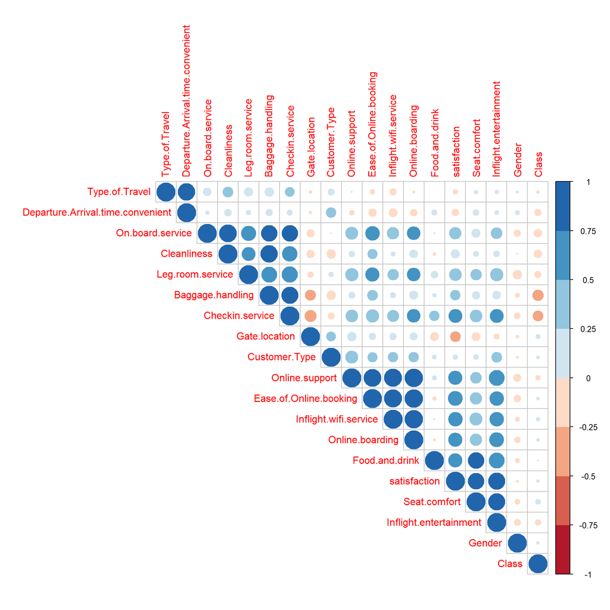

```r
c=cor(pca_df2)
corrplot(c, type="upper", order="hclust",col=brewer.pal(n=8, name="RdBu"))
```

using the correlation plot, we remark some interesting correlations between some variables.

```r
acp=PCA(pca_df2,quali.sup = c(1:5),graph=F)
acp$eig
```

```
##          eigenvalue percentage of variance cumulative percentage of variance
## comp 1  6.313287177            45.09490840                          45.09491
## comp 2  2.787664699            19.91189071                          65.00680
## comp 3  2.128877348            15.20626677                          80.21307
## comp 4  1.011249588             7.22321135                          87.43628
## comp 5  0.656924237             4.69231598                          92.12859
## comp 6  0.448076690             3.20054779                          95.32914
## comp 7  0.262922187             1.87801562                          97.20716
## comp 8  0.195015696             1.39296926                          98.60013
## comp 9  0.096628894             0.69020638                          99.29033
## comp 10 0.037298670             0.26641907                          99.55675
## comp 11 0.030826578             0.22018984                          99.77694
## comp 12 0.016403057             0.11716469                          99.89411
## comp 13 0.008019785             0.05728418                          99.95139
## comp 14 0.006805394             0.04860996                         100.00000
```

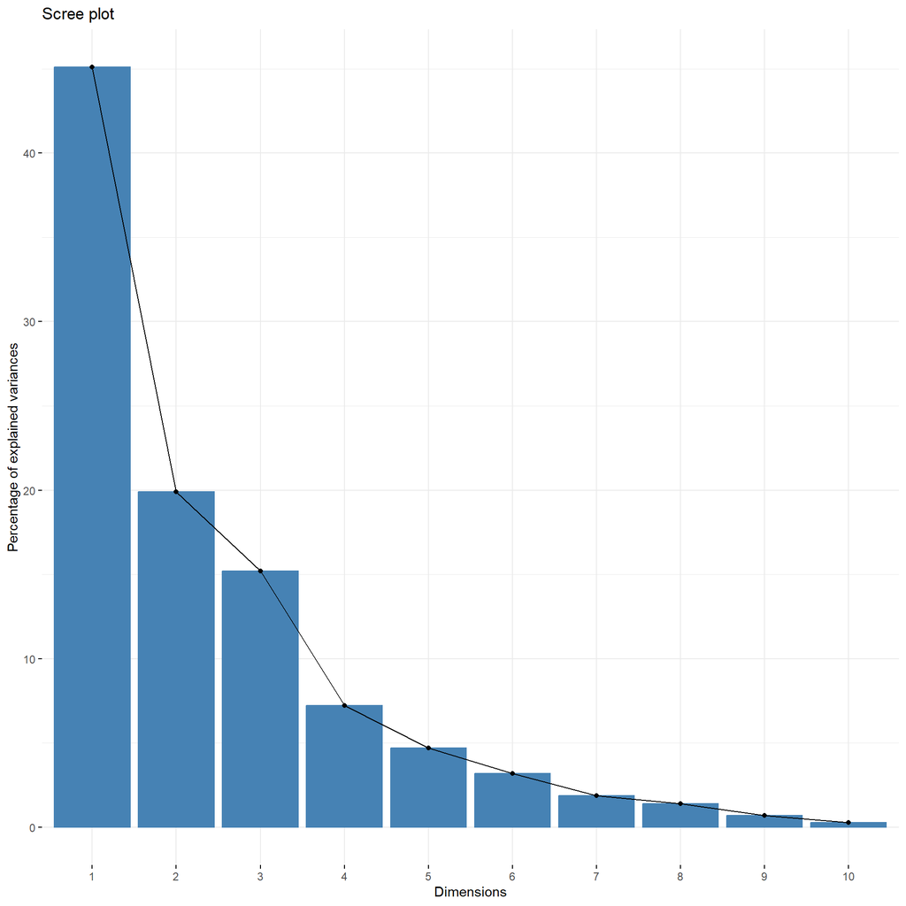

```r
fviz_screeplot(acp, ncp=10)
```

for this PCA, we will be taking 5 axes for better clustering results later.

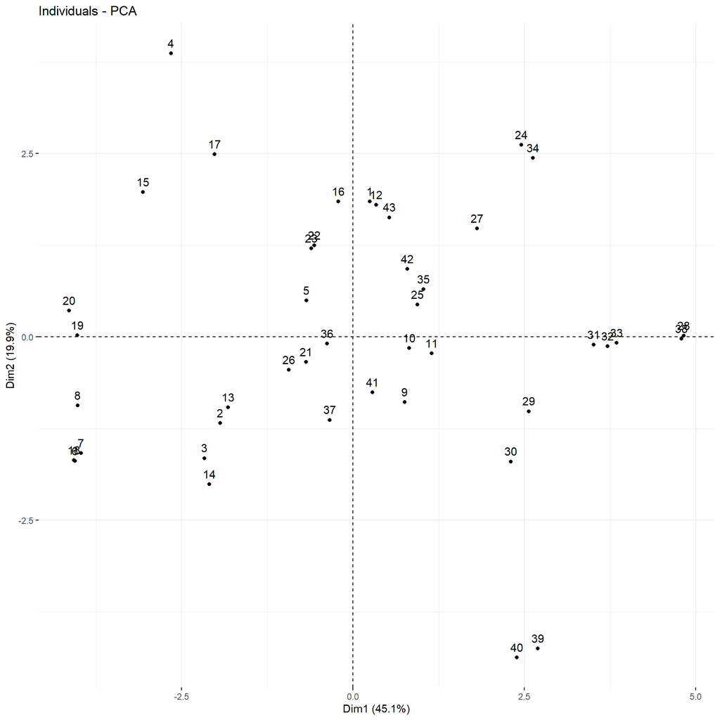

```r
fviz_pca_ind(acp)
```

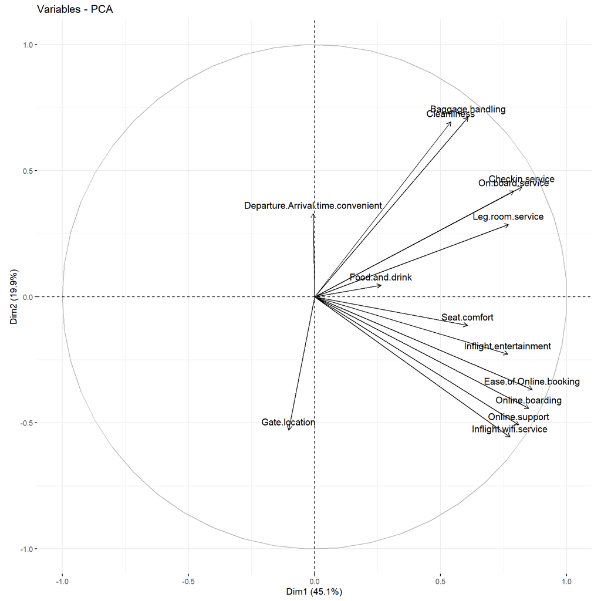

```r
fviz_pca_var(acp)
```

For now, we could not interpret anything and we need to perform some clustering methods for better results.

## 4.2 Clustering methods

### 4.2.1 determine the best number of classes

for this part, we will be using the **NbClust** method.

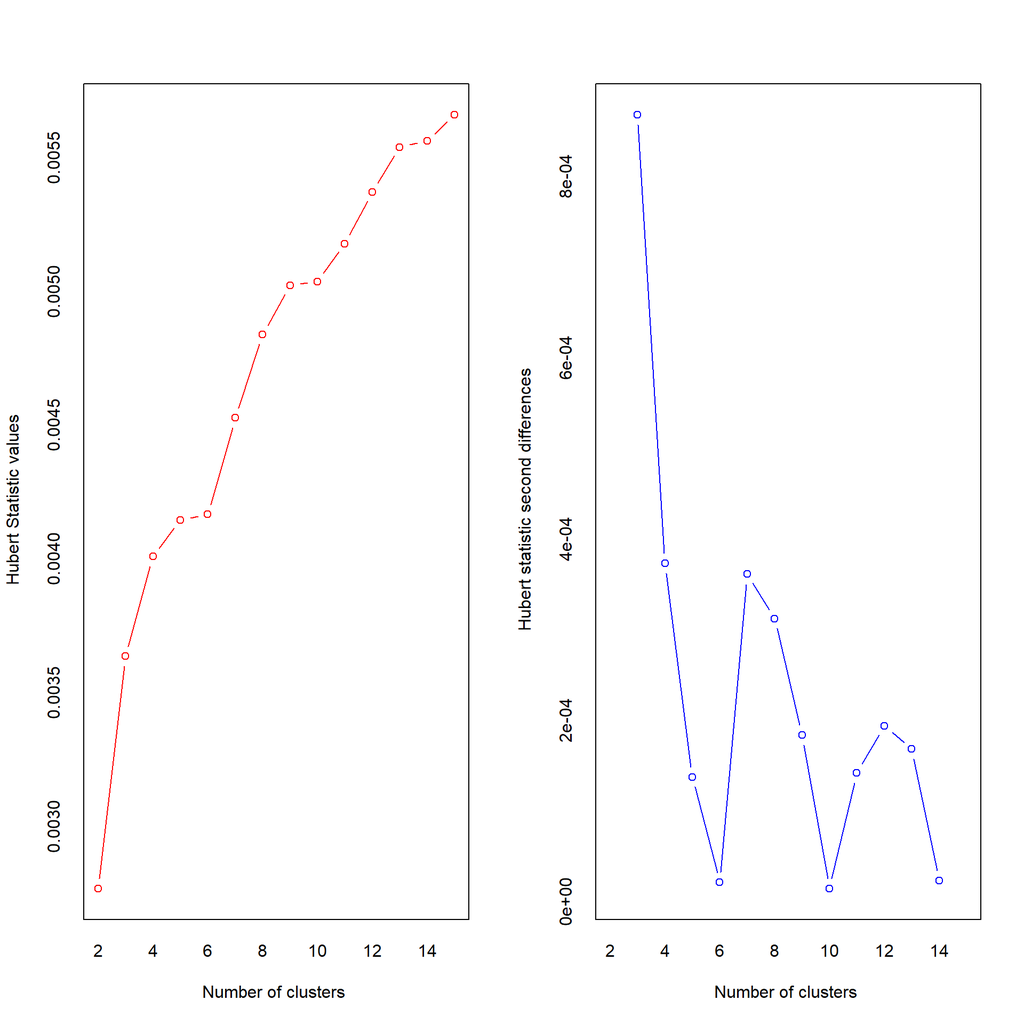

```
## *** : The Hubert index is a graphical method of determining the number of clusters.
##                 In the plot of Hubert index, we seek a significant knee that corresponds to a
##                 significant increase of the value of the measure i.e the significant peak in Hubert
##                 index second differences plot.
##
```

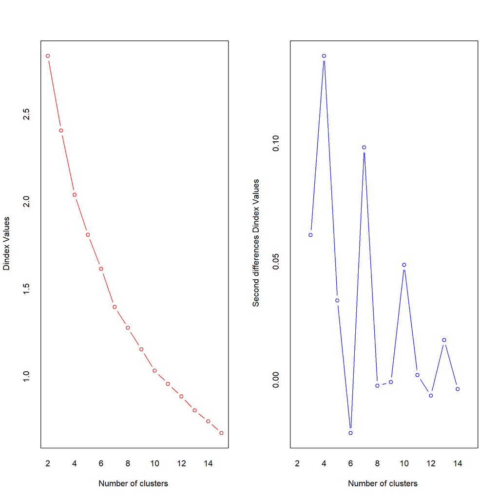

```
## *** : The D index is a graphical method of determining the number of clusters.
##                 In the plot of D index, we seek a significant knee (the significant peak in Dindex
##                 second differences plot) that corresponds to a significant increase of the value of
##                 the measure.
##
## * Among all indices:
## * 4 proposed 2 as the best number of clusters
## * 2 proposed 3 as the best number of clusters
## * 7 proposed 4 as the best number of clusters
## * 1 proposed 6 as the best number of clusters
## * 1 proposed 7 as the best number of clusters
## * 3 proposed 14 as the best number of clusters
## * 5 proposed 15 as the best number of clusters
##
##                    ***** Conclusion *****
##
## * According to the majority rule, the best number of clusters is  4
##
##
```

```
##  1  2  3  4  5  6  7  8  9 10 11 12 13 14 15 16 17 18 19 20 21 22 23 24 25 26
##  1  2  2  1  1  2  2  2  3  3  3  1  2  2  1  1  1  2  2  2  1  1  1  3  3  3
## 27 28 29 30 31 32 33 34 35 36 37 38 39 40 41 42 43
##  3  4  4  4  4  4  4  3  3  3  3  4  4  4  3  3  3
```

```r
NbClust(acp$ind$coord,method='ward.D')$Best.partition
```

As the function gives, the best number of classes is **4**.

### 4.2.2 Hierarchical clustering

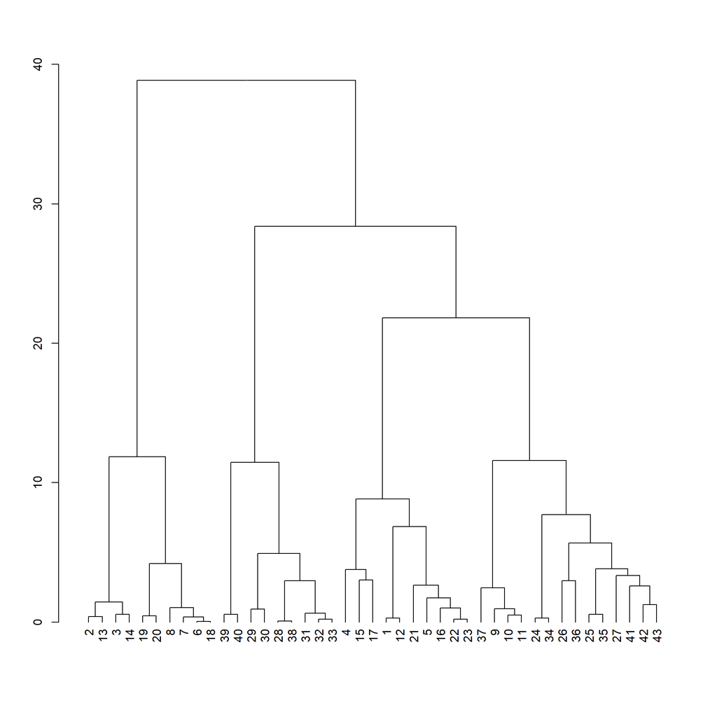

```r
d=dist(acp$ind$coord)
clust=hclust(d,method="ward.D")
dend=as.dendrogram(clust)
plot(dend)
```

by the graph, the number of classes is between **2** or **4**. but we will be using the result of the **NbClust** function.

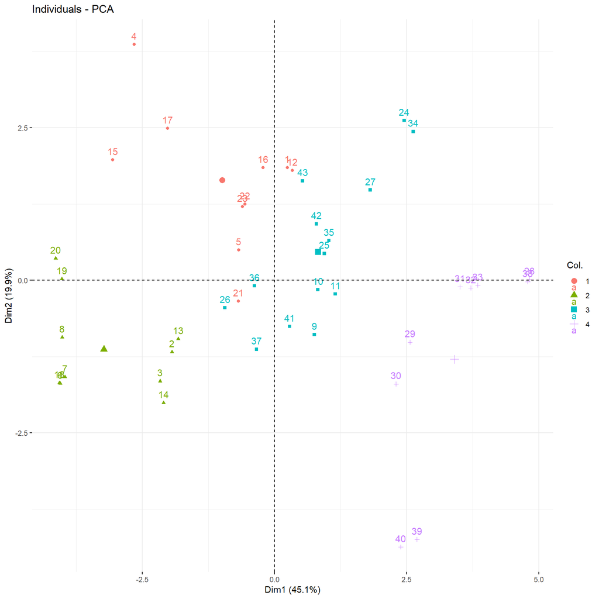

```r
clusters=cutree(clust,k=4)
df_final=cbind(pca_df2,Classes=as.factor(clusters))
fviz_pca_ind(acp,col.ind=df_final$Classes)
```

### 4.2.3 K-Means

This is the second method of clustering.

```r
km=kmeans(as.matrix(df_final), centers = 4)
km
```

```
## K-means clustering with 4 clusters of sizes 9, 10, 14, 10
##
## Cluster means:
##   satisfaction   Gender Customer.Type Type.of.Travel Class Seat.comfort
## 1     2.000000 1.333333      2.000000       1.333333   2.0     4.466273
## 2     1.000000 1.500000      1.600000       1.000000   2.2     3.401609
## 3     1.785714 1.500000      1.428571       1.571429   2.0     4.673429
## 4     1.000000 1.700000      1.300000       1.800000   1.7     3.485829
##   Departure.Arrival.time.convenient Food.and.drink Gate.location
## 1                          3.968077       3.931826      3.988933
## 2                          3.680298       3.771885      4.060349
## 3                          4.250254       4.609245      3.911851
## 4                          4.483059       3.437393      3.899266
##   Inflight.wifi.service Inflight.entertainment Online.support
## 1              4.663843               4.928928       4.964475
## 2              3.805119               3.584057       3.839691
## 3              4.071311               4.614756       4.142987
## 4              3.857962               3.504272       3.841796
##   Ease.of.Online.booking On.board.service Leg.room.service Baggage.handling
## 1               5.067188         4.625432         4.628452         3.675507
## 2               3.687825         3.604744         3.908823         3.041054
## 3               4.029175         4.233420         4.356788         3.622989
## 4               3.880763         4.348836         4.178836         3.768918
##   Checkin.service Cleanliness Online.boarding Classes
## 1        4.400804    4.685574        4.817029       4
## 2        3.597194    4.033010        3.711728       2
## 3        4.436412    4.614943        4.089940       3
## 4        4.257836    4.867092        3.867064       1
##
## Clustering vector:
##  1  2  3  4  5  6  7  8  9 10 11 12 13 14 15 16 17 18 19 20 21 22 23 24 25 26
##  4  2  2  4  4  2  2  2  3  3  3  4  2  2  4  4  4  2  2  2  4  4  4  3  3  3
## 27 28 29 30 31 32 33 34 35 36 37 38 39 40 41 42 43
##  3  1  1  1  1  1  1  3  3  3  3  1  1  1  3  3  3
##
## Within cluster sum of squares by cluster:
## [1] 21.28239 18.18594 38.17519 27.61126
##  (between_SS / total_SS =  60.0 %)
##
## Available components:
##
## [1] "cluster"      "centers"      "totss"        "withinss"     "tot.withinss"
## [6] "betweenss"    "size"         "iter"         "ifault"
```

### 4.2.4 Comparing the two methods

In order to compare the two method, we have to compare the result of clustering, for that reason we will be using the **table** function

```r
table(km$cluster,clusters)
```

```
##    clusters
##      1  2  3  4
##   1  0  0  0  9
##   2  0 10  0  0
##   3  0  0 14  0
##   4 10  0  0  0
```

as we can see, the two method gave the exact same results, just with different names. which make this distribution a perfect one.

## 4.3 Interpreting the results

for this part, we will use the **catdes** function.

```r
catdes(df_final,num.var = length(df_final))
```

```
##
## Link between the cluster variable and the quantitative variables
## ================================================================
##                                        Eta2      P-value
## Inflight.entertainment            0.8401274 1.391398e-15
## Ease.of.Online.booking            0.8336022 3.024395e-15
## Seat.comfort                      0.7967721 1.461181e-13
## satisfaction                      0.7796584 6.998142e-13
## Food.and.drink                    0.7552236 5.359465e-12
## Online.support                    0.7209842 6.736772e-11
## Online.boarding                   0.6889455 5.492831e-10
## Inflight.wifi.service             0.6469188 6.314475e-09
## Checkin.service                   0.6406495 8.859885e-09
## On.board.service                  0.5274790 1.687339e-06
## Leg.room.service                  0.4286089 6.243420e-05
## Baggage.handling                  0.4063092 1.286122e-04
## Cleanliness                       0.3942368 1.879043e-04
## Type.of.Travel                    0.3372180 1.013663e-03
## Departure.Arrival.time.convenient 0.2807364 4.614870e-03
## Customer.Type                     0.2523496 9.384189e-03
## Gate.location                     0.1982273 3.320153e-02
##
## Description of each cluster by quantitative variables
## =====================================================
## $`1`
##                                      v.test Mean in category Overall mean
## Type.of.Travel                     2.572800         1.800000     1.441860
## Departure.Arrival.time.convenient  2.387779         4.483058     4.112786
## Cleanliness                        2.335235         4.867092     4.553032
## Inflight.wifi.service             -2.045285         3.857962     4.083808
## Online.support                    -2.356454         3.841796     4.174348
## Seat.comfort                      -3.150832         3.485829     4.058113
## satisfaction                      -3.326739         1.000000     1.465116
## Inflight.entertainment            -3.657668         3.504272     4.182563
## Food.and.drink                    -3.830197         3.437393     4.000201
##                                   sd in category Overall sd      p.value
## Type.of.Travel                         0.4000000  0.4966083 0.0100879575
## Departure.Arrival.time.convenient      0.5914998  0.5532159 0.0169505159
## Cleanliness                            0.3888512  0.4797878 0.0195311736
## Inflight.wifi.service                  0.3275167  0.3939365 0.0408268020
```

[output cut: 62 more lines]

```
## Leg.room.service       3.169215         4.628452     4.268086      0.4029844
## Customer.Type          2.966727         2.000000     1.558140      0.0000000
## On.board.service       2.931451         4.625432     4.196106      0.3980407
## Seat.comfort           2.100310         4.466273     4.058113      0.4949797
##                        Overall sd      p.value
## Ease.of.Online.booking  0.5443980 1.037164e-08
## Online.support          0.5034637 1.669510e-07
## Online.boarding         0.4748023 5.194925e-07
## Inflight.wifi.service   0.3939365 9.132645e-07
## Inflight.entertainment  0.6615759 1.687992e-04
## satisfaction            0.4987816 3.493548e-04
## Leg.room.service        0.3791394 1.528514e-03
## Customer.Type           0.4966083 3.009878e-03
## On.board.service        0.4883274 3.373823e-03
## Seat.comfort            0.6479685 3.570160e-02
```

**Class 1** : represents the customers who are slightly dissatisfied but the have a little bit of satisfaction just because it is for **personal travel**.  
**Class 2** : represents the customers who are disappointed and totally dissatisfied with everything in the flight  
**Class 3** : represents the customers who are slightly satisfied with the flight and some of its services.  
**Class 4** : represents the customers who are fully satisfied with everything in the flight and all its pre-flight services and this class is for the **loyal customers**.

# 5 Regression

## 5.1 Train / Test data split

in this part we will split the whole data in two parts, one for training the model and the other for testing it.  
as we almost have **130000** observations in the dataframe so will have **100000** for training and the rest for testing.

```r
x=sample(c(1:nrow(df)),100000)

df_train=df[x,]
df_test=df[-x,]

nrow(df_train)
```

```
## [1] 100000
```

```r
nrow(df_test)
```

```
## [1] 29880
```

## 5.2 Logistic Regression

In this part we will use the **step** function to estimate the best equation to use on the **glm** model.

```r
df_train$satisfaction=as.factor(ifelse(df_train$satisfaction=='satisfied',1,0))
df_test$satisfaction=as.factor(ifelse(df_test$satisfaction=='satisfied',1,0))
modele_glm=glm(satisfaction ~ .,family='binomial',df_train)
step(modele_glm,direction='both')
```

```
## Start:  AIC=77030.97
## satisfaction ~ Gender + Customer.Type + Age + Type.of.Travel +
##     Class + Flight.Distance + Seat.comfort + Departure.Arrival.time.convenient +
##     Food.and.drink + Gate.location + Inflight.wifi.service +
##     Inflight.entertainment + Online.support + Ease.of.Online.booking +
##     On.board.service + Leg.room.service + Baggage.handling +
##     Checkin.service + Cleanliness + Online.boarding + Departure.Delay.in.Minutes +
##     Arrival.Delay.in.Minutes
##
##                                     Df Deviance   AIC
## <none>                                    76983 77031
## - Departure.Delay.in.Minutes         1    76994 77040
## - Cleanliness                        1    77033 77079
## - Inflight.wifi.service              1    77034 77080
## - Arrival.Delay.in.Minutes           1    77066 77112
## - Online.support                     1    77069 77115
## - Baggage.handling                   1    77107 77153
## - Flight.Distance                    1    77119 77165
## - Age                                1    77135 77181
## - Gate.location                      1    77170 77216
## - Online.boarding                    1    77201 77247
## - Ease.of.Online.booking             1    77258 77304
## - Food.and.drink                     1    77410 77456
## - Departure.Arrival.time.convenient  1    77632 77678
## - Seat.comfort                       1    77733 77779
## - Leg.room.service                   1    77767 77813
## - Type.of.Travel                     1    77844 77890
## - Class                              2    77998 78042
## - On.board.service                   1    78114 78160
## - Checkin.service                    1    78419 78465
## - Gender                             1    79622 79668
## - Customer.Type                      1    82133 82179
## - Inflight.entertainment             1    82835 82881
```

```
##
## Call:  glm(formula = satisfaction ~ Gender + Customer.Type + Age + Type.of.Travel +
##     Class + Flight.Distance + Seat.comfort + Departure.Arrival.time.convenient +
##     Food.and.drink + Gate.location + Inflight.wifi.service +
##     Inflight.entertainment + Online.support + Ease.of.Online.booking +
##     On.board.service + Leg.room.service + Baggage.handling +
##     Checkin.service + Cleanliness + Online.boarding + Departure.Delay.in.Minutes +
##     Arrival.Delay.in.Minutes, family = "binomial", data = df_train)
##
## Coefficients:
##                       (Intercept)                         GenderMale
##                        -6.8225923                         -0.9486538
##       Customer.TypeLoyal Customer                                Age
##                         1.9597902                         -0.0079970
##     Type.of.TravelPersonal Travel                           ClassEco
##                        -0.7805398                         -0.7246104
##                     ClassEco Plus                    Flight.Distance
##                        -0.8093581                         -0.0001141
##                      Seat.comfort  Departure.Arrival.time.convenient
##                         0.2845685                         -0.1955998
##                    Food.and.drink                      Gate.location
##                        -0.2183493                          0.1187589
##             Inflight.wifi.service             Inflight.entertainment
##                        -0.0720360                          0.6887585
##                    Online.support             Ease.of.Online.booking
##                         0.0955004                          0.2194085
##                  On.board.service                   Leg.room.service
##                         0.3127895                          0.2237870
##                  Baggage.handling                    Checkin.service
##                         0.1177943                          0.2958699
##                       Cleanliness                    Online.boarding
##                         0.0773052                          0.1673123
##        Departure.Delay.in.Minutes           Arrival.Delay.in.Minutes
##                         0.0030678                         -0.0082138
##
## Degrees of Freedom: 99999 Total (i.e. Null);  99976 Residual
## Null Deviance:       137700
## Residual Deviance: 76980     AIC: 77030
```

As we can see the result the **step** function, it kept all the given variables as they are all dependent to the target variable. So we will keep the model as it is and we will proceed to the prediction function.

```r
pred_glm=predict(modele_glm,df_test,type='response')
pred_glm=ifelse(pred_glm>0.5,1,0)
tab=table(df_test$satisfaction,pred_glm)
print(paste("The accuracy = ",(tab[1,1]+tab[2,2])/sum(tab)))
```

```
## [1] "The accuracy =  0.835809906291834"
```

```r
print(paste("The precision = ",tab[2,2]/(tab[1,2]+tab[2,2])))
```

```
## [1] "The precision =  0.849682384559003"
```

here is the result of the prediction shows that the accuracy and the precision of the model are more than **80%** which is high enough to accept the model.  
And here is the AUC graph of the **glm** model.

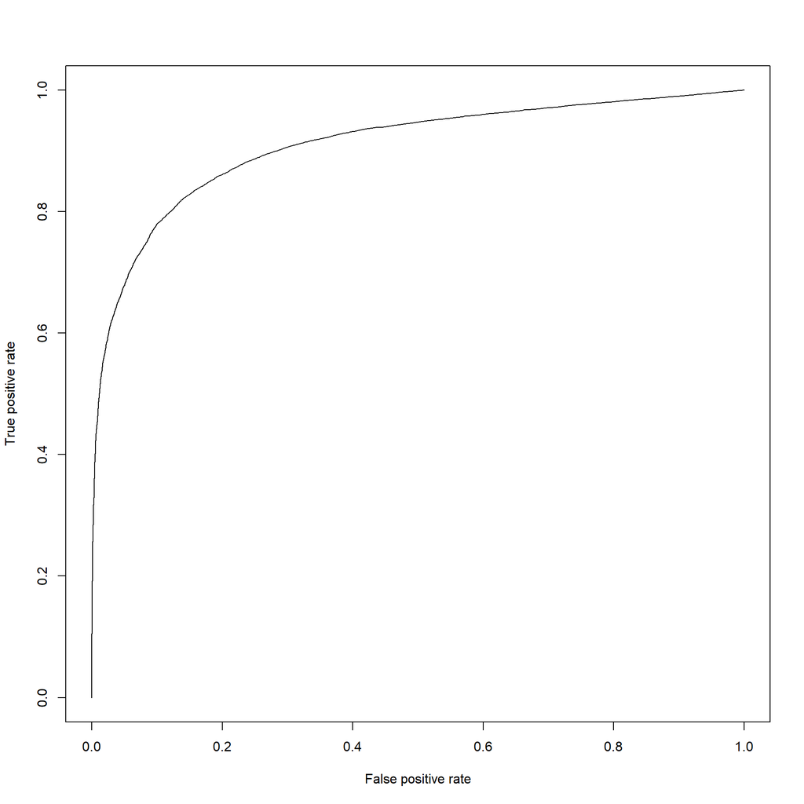

```r
pred=predict(modele_glm,df_test,type="response")
predicted=prediction(pred,df_test$satisfaction)
roc=performance(predicted, "tpr","fpr")
plot(roc)
```

```r
auc=performance(predicted, "auc")
auc@y.values
```

```
## [[1]]
## [1] 0.9091909
```

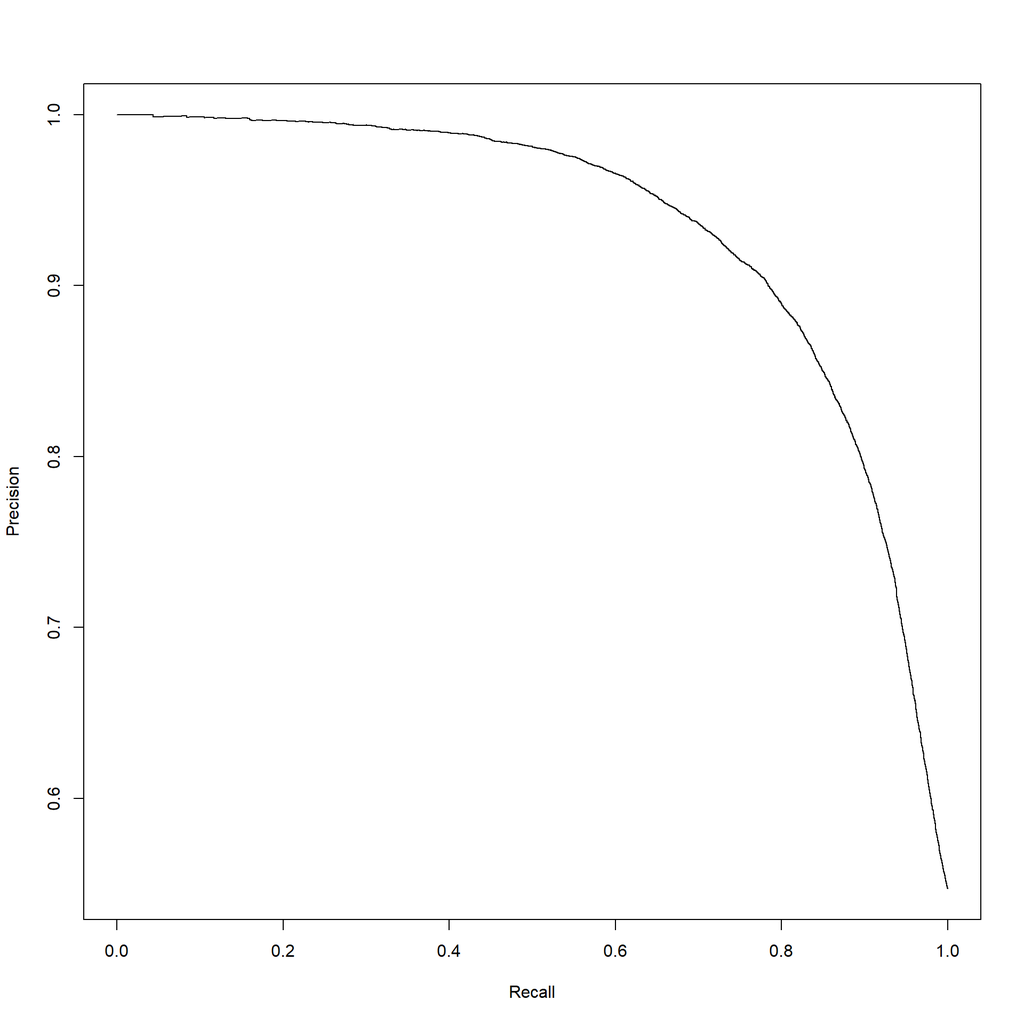

```r
proc=performance(predicted, "prec","rec")
plot(proc)
```

```r
aucpr=performance(predicted, "aucpr")
aucpr@y.values
```

```
## [[1]]
## [1] 0.9340118
```

## 5.3 Factorial Discriminant Analysis

Here is another method to make a model for prediction of the target variable with the factorial discriminant analysis using the **lda** function.

```r
modele_lda=lda(satisfaction ~ .,df_train)
pred_lda=predict(modele_lda,prior=c(0.5,0.5),df_test)
tab=table(df_test$satisfaction,pred_lda$class)
print(paste("The accuracy = ",(tab[1,1]+tab[2,2])/sum(tab)))
```

```
## [1] "The accuracy =  0.839825970548862"
```

```r
print(paste("The precision = ",tab[2,2]/(tab[1,2]+tab[2,2])))
```

```
## [1] "The precision =  0.868330574302814"
```

This model gives an accuracy and precision also above **80%** which means that this model is accurate as well.

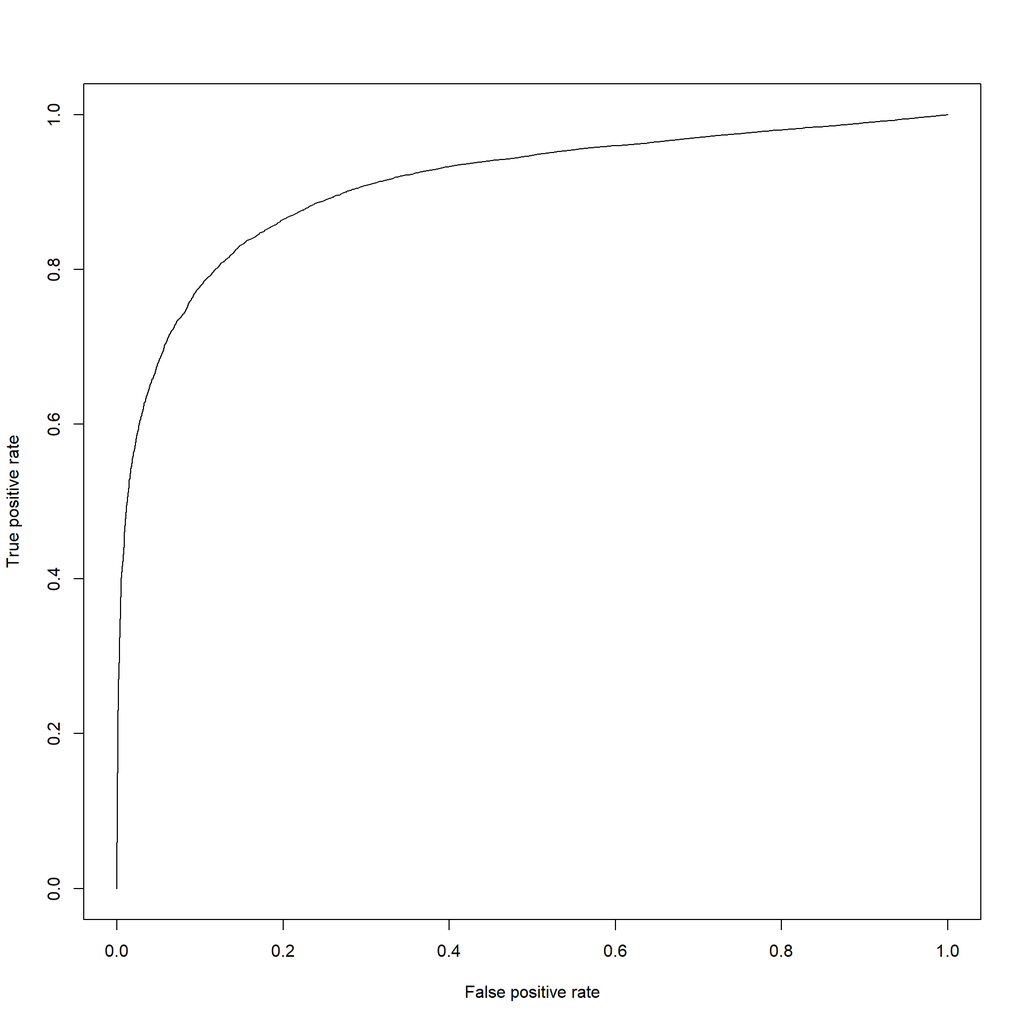

```r
predicted=prediction(pred_lda$posterior[,2],df_test$satisfaction)
roc=performance(predicted, "tpr","fpr")
plot(roc)
```

```r
auc=performance(predicted, "auc")
auc@y.values
```

```
## [[1]]
## [1] 0.9095446
```

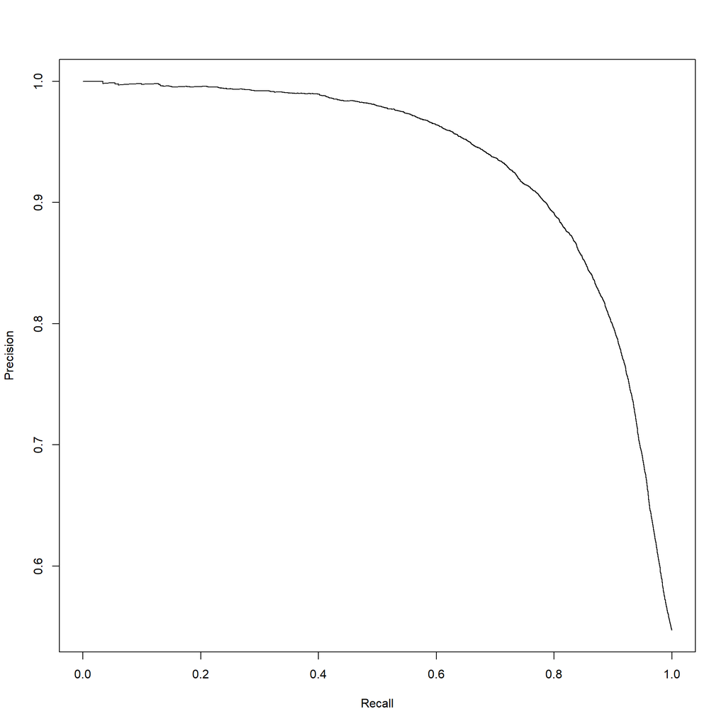

```r
proc=performance(predicted, "prec","rec")
plot(proc)
```

```r
aucpr=performance(predicted, "aucpr")
aucpr@y.values
```

```
## [[1]]
## [1] 0.9337687
```

## 5.4 Decision Tree

in this part we will create a decision tree model

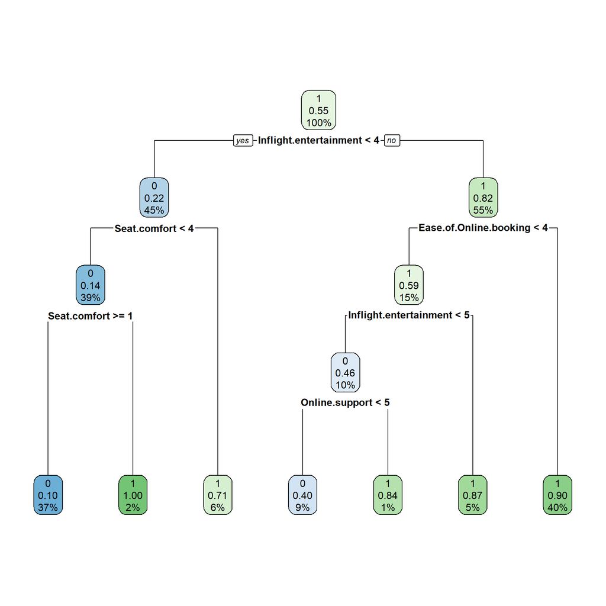

```r
rc=rpart.control(minsplit = 20)
tree=rpart(satisfaction~.,data=df_train,method="class",control = rc)
pred_tree=predict(tree,df_test,type = "class")
rpart.plot(tree,extra = 106)
```

```r
tab=table(df_test$satisfaction,pred_tree)
print(paste("The accuracy = ",(tab[1,1]+tab[2,2])/sum(tab)))
```

```
## [1] "The accuracy =  0.865327978580991"
```

```r
print(paste("The precision = ",tab[2,2]/(tab[1,2]+tab[2,2])))
```

```
## [1] "The precision =  0.882269063856169"
```

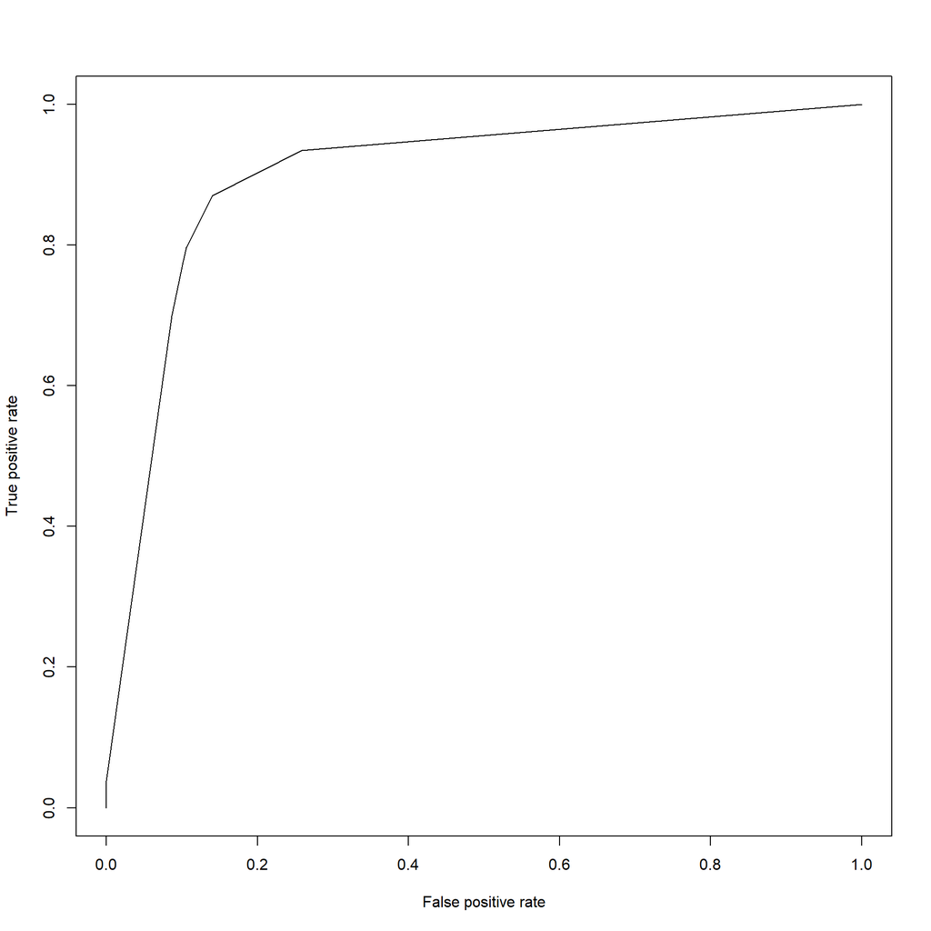

```r
pred=predict(tree,df_test,type = "prob")[,2]
predicted=prediction(pred,df_test$satisfaction)
roc=performance(predicted, "tpr","fpr")
plot(roc)
```

```r
auc=performance(predicted, "auc")
auc@y.values
```

```
## [[1]]
## [1] 0.8989016
```

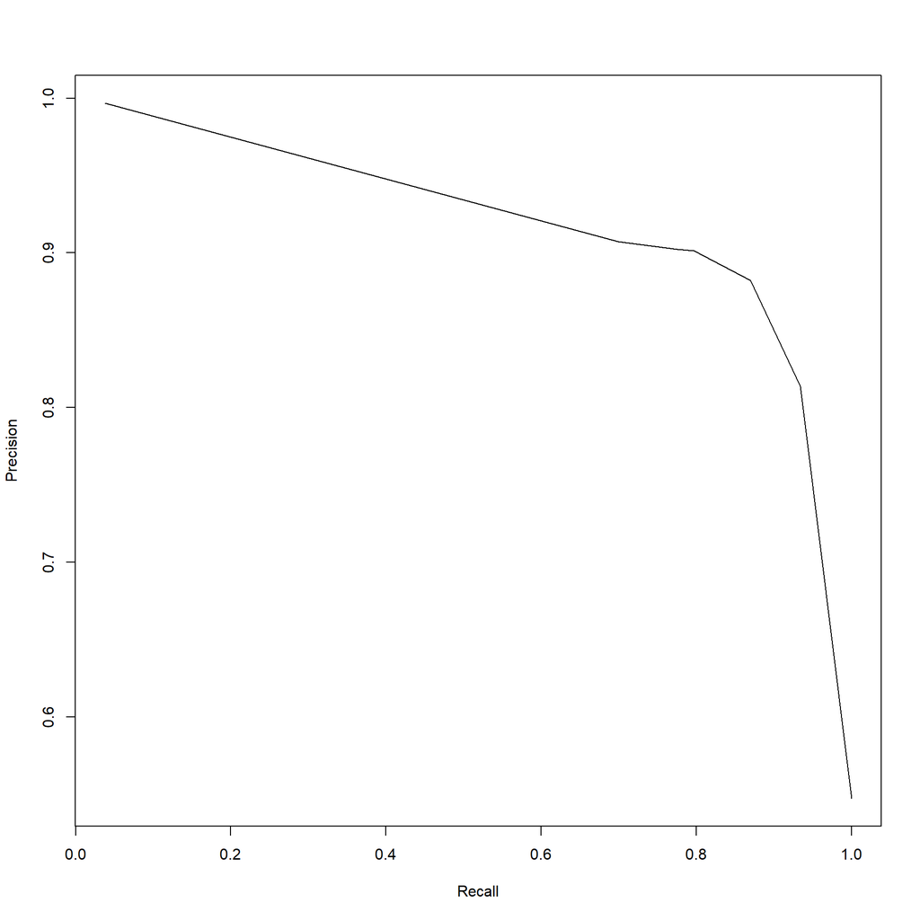

```r
proc=performance(predicted, "prec","rec")
plot(proc)
```

```r
aucpr=performance(predicted, "aucpr")
aucpr@y.values
```

```
## [[1]]
## [1] 0.9041347
```

## 5.5 RandomForest

```r
tuneRF(df_train[setdiff(colnames(df_train),"satisfaction")],df_train$satisfaction,stepFactor=1.5,mtryStart=2, improve=0.01,ntree=20,trace=F)
```

```
## 0.1525091 0.01
## 0.0243473 0.01
## 0.06841031 0.01
## 0.02231894 0.01
## -0.01395697 0.01
```

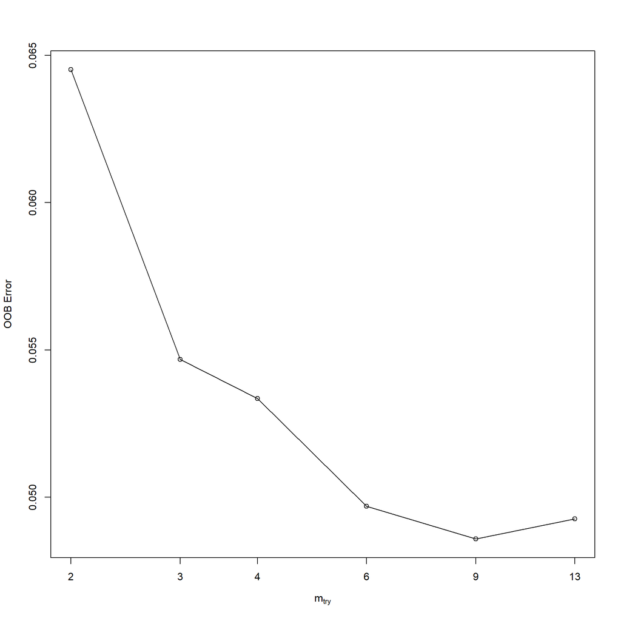

```
##        mtry   OOBError
## 2.OOB     2 0.06451516
## 3.OOB     3 0.05467601
## 4.OOB     4 0.05334480
## 6.OOB     6 0.04969547
## 9.OOB     9 0.04858632
## 13.OOB   13 0.04926443
```

As the **tuneRF** function gives, its optimal to use **9** mtry variables as it has the least OOB error.  
Now we will apply a random forest model:

```r
modele_rf=randomForest(satisfaction~.,data=df_train,ntree=20,mtry=9)
pred=predict(modele_rf,df_test,type="class")
tab=table(df_test$satisfaction,pred)
print(paste("The accuracy = ",(tab[1,1]+tab[2,2])/sum(tab)))
```

```
## [1] "The accuracy =  0.956492637215529"
```

```r
print(paste("The precision = ",tab[2,2]/(tab[1,2]+tab[2,2])))
```

```
## [1] "The precision =  0.970264867566217"
```

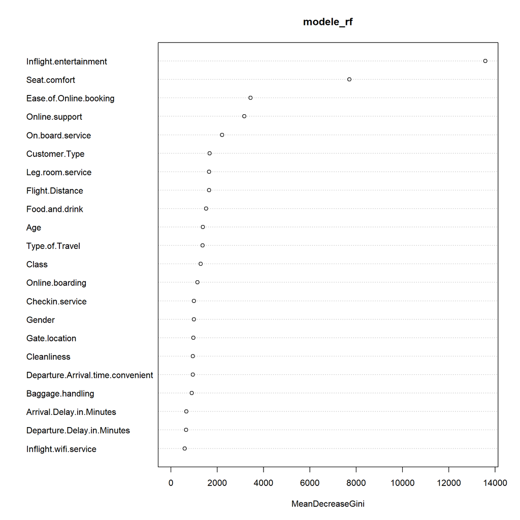

```r
varImpPlot(modele_rf)
```

this graph shows the most important variables in the classification model and it shows that **Inflight entertainment** is the most crucial variable and that’s what we saw with the decision tree.  
And lastly we represent the AUC plot of this model.

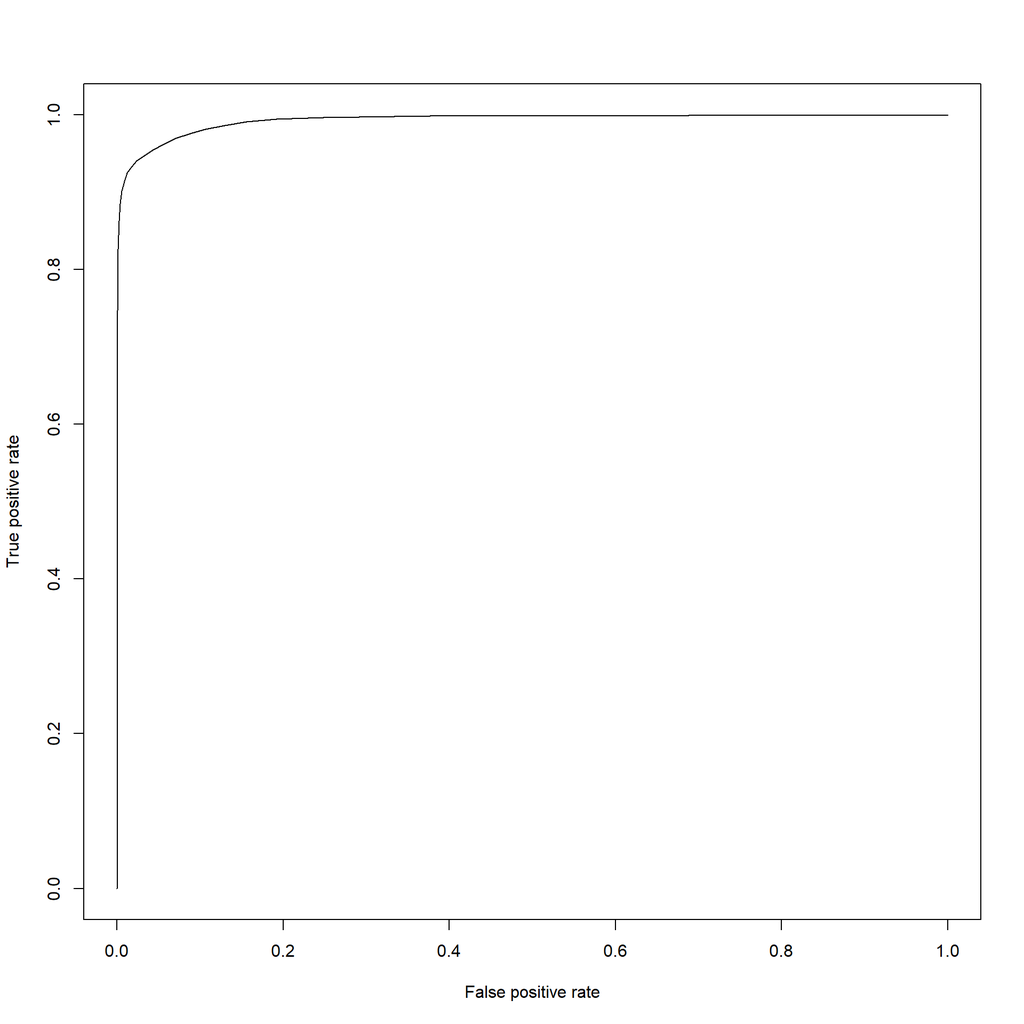

```r
pred=predict(modele_rf,df_test,type="prob")[,2]
predicted=prediction(pred,df_test$satisfaction)
roc=performance(predicted, "tpr","fpr")
plot(roc)
```

```r
auc=performance(predicted, "auc")
auc@y.values
```

```
## [[1]]
## [1] 0.992734
```

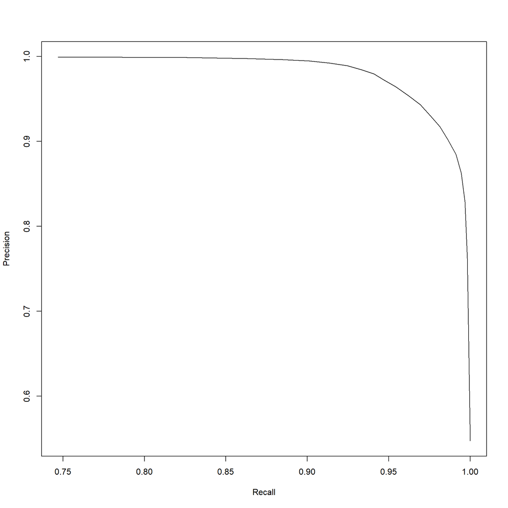

```r
proc=performance(predicted, "prec","rec")
plot(proc)
```

```r
aucpr=performance(predicted, "aucpr")
aucpr@y.values
```

```
## [[1]]
## [1] 0.9949422
```